# ISoP Student Metrics Munch (M&M) Newsletter

## **ISoP Student Metrics Munch (M&M) Newsletter**

2020-07-06

Hello, Aspirant Pharmacometricians!

We are very excited to present our very *first* issue of our monthly newsletter.

# Contents

> **Message from the Chair**

> **SCIENTIST SPOTLIGHT**

> **Get to Know Your Members**

> **Virtual Meeting**

> **Looking for Jobs/Internships?**

> **Join the ISoP/ISoP Student Community**

**Message from the Chair**

By *Ashwin Karanam*

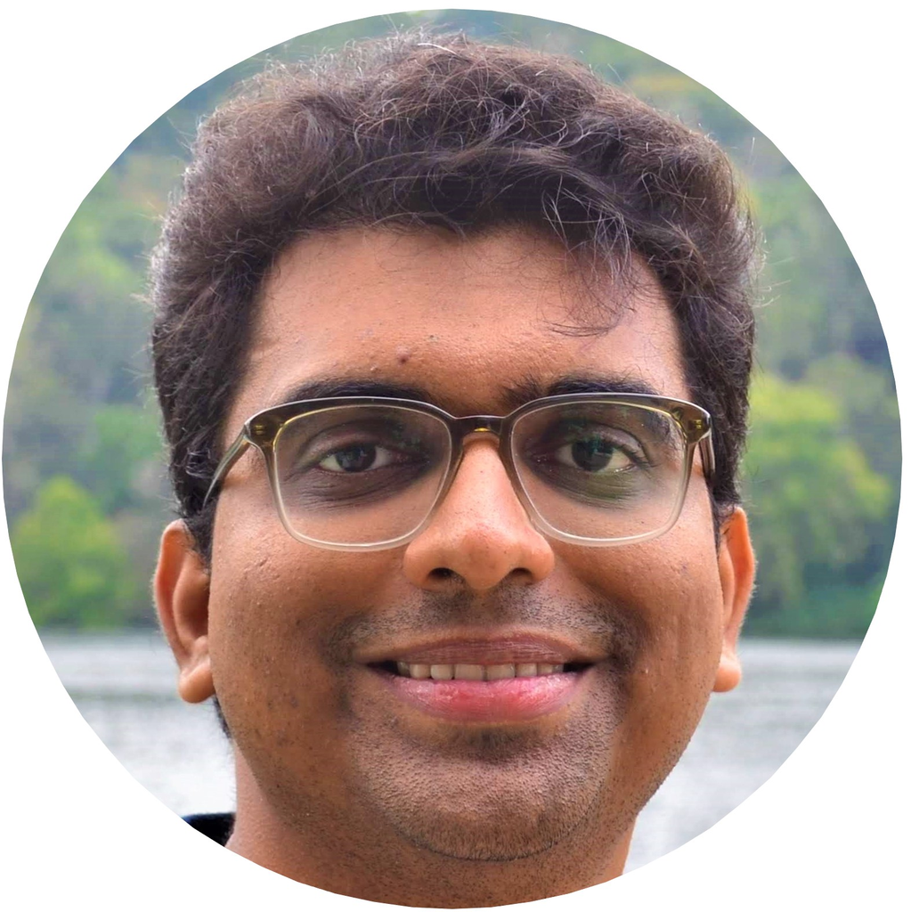

It is my great pleasure to introduce you to the first issue of the ISoP Student Community’s newsletter “Metrics and Munch”. The newsletter has been in talks within the student community for around 2 years and it has only come to fruition after a lot of deliberation and discussion. The Student Community identified that there is a need for improved communication and networking within the student community and the newsletter is the perfect medium to start with.

The newsletter features senior graduate students and their research, fun articles to expand reader’s knowledge, and jobs/internships corner for a one stop section for trainees to find latest job and internship postings. Many upcoming events within the Student Community can also be found in the newsletter. In the upcoming months, we will be launching several events including online mentoring sessions, trainee driven webinars, and many more to come. In these challenging pandemic times, we are hoping that this newsletter provides readers with more opportunities to stay connected within the trainee fraternity.

It goes without saying but the Student Community is grateful to the Student Communications Committee led by Ya-Feng Wen and his team (Shen Cheng, Mutaz Jaber, Anne-Grete Märtson, and Zaid Temrikar) who have worked hard over the past months to bring you this newsletter. In addition, a thank you to my fellow Student Leadership Team members (Chair-elect – Brian Cicali, Secretary – Patrick Hanafin, and Past-Chair – Kayla Lien) for all their support in this endeavor. Last but not the least, none of this would have been possible without the support of the ISoP Board Liaison for the Student Community Dr. Vijay Ivaturi. His encouragement had the biggest impetus for this venture.

As always, we encourage trainees to join the ISoP Student Community. You can find details about how to volunteer on our [website](https://isop-student-community.github.io/isop-student-community/). We also have an ISoP Student-specific Category for student discussion can be found on the forum. We highly encourage trainees to visit and post any topics you would like to discuss.

I hope this newsletter motivates you to join the community. We welcome all kinds of suggestions and feedback, and we look forward to hearing from all of you!

### **SCIENTIST SPOTLIGHT**

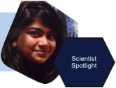

| **Lubna: From Physics doctorate to building Parainfluenza models!**

The webinar will be held on July 15, 2020, from 1PM to 2 PM EST.

[Register for the webinar](https://www.eventbrite.com/e/mechanics-of-influenza-like-viruses-tickets-110566122248)

### **Get to Know Your Members**

[figure not shown]

| **Two Lies and a Truth–ISoP Student Member edition! The individual with the most correct answers will be featured in the next M&M Newsletter!** (Close on Sat, July 25, 2020, 8 AM EST)

[Play the game](https://docs.google.com/forms/d/e/1FAIpQLSd6xP15ktuLEDTUg-DH1Qzqn6Px9BScBpuQJVBvcRe1XKZ1jQ/viewform)

### **Virtual meeting**

[figure not shown]

| **Virtual Networking Meet and Greet via Zoom Breakout Rooms**

The networking event will be held on July 25, 2020, from 8 AM to 9 AM EST.

[Register for the networking event](https://www.eventbrite.com/e/isop-student-communications-committee-virtual-games-meet-greet-network-tickets-110563357980)

### **Looking for Jobs/Internships?**

Jobs and internships in Pharmacometrics/ Clinical Pharmacology around the globe

[View the lists](https://docs.google.com/document/d/1ZCmS4n4Zme9-XzfvQ1j_c1mRWU3vPjRWiNy1B85SUHk/edit)

### **Join the ISoP/ISoP Student Community**

[Join as a ISoP Member](http://go-isop.org/benefits/)

[Join the ISoP student Community](https://isop-student-community.github.io/isop-student-community/vol.html)

**Thank you!**

*ISoP Student Communication team*

- If you want to be added to the ISoP Communications email list, please contact Zaid Temrikar: ztemrika@uthsc.edu
- If you have ideas for events, please email Zaid Temrikar: ztemrika@uthsc.edu or Anne-Grete Märtson: a.martson@umcg.nl